```python
# Eric Uehling 5.1.2023
```

# Analyzing the Impact of the COVID-19 Pandemic on VT Student Performance

The COVID-19 pandemic has significantly transformed the educational landscape for countless students worldwide. As universities rapidly transitioned to remote learning, students found themselves attending Zoom lectures, taking online tests, and submitting digital assignments. This abrupt change in the learning environment has led many to speculate whether the pandemic made college easier, potentially contributing to higher average grade point averages (GPAs). To better understand this phenomenon, we aim to explore the following question and hypothesis:

Central Question: Did online learning lead to an increase in student GPAs during the COVID-19 pandemic? Hypothesis: I propose that, due to the decreased accountability experienced by many students, their academic performance improved during the pandemic compared to pre-pandemic levels.

Dataset: https://udc.vt.edu/irdata/data/courses/grades

Methodology: Utilizing GPA data from Virginia Tech, I will examine the differences in average GPAs across three distinct time periods: pre-pandemic (before Spring 2020), pandemic (between Spring 2020 and Spring 2021), and post-pandemic (after Spring 2021). This analysis will be conducted on both aggregate and course-by-course levels. Subsequently, I will visualize these GPA splits to discern any notable discrepancies between the time periods, calculating the average GPA using the course/time period mean. Furthermore, I will assess the impact of the pandemic on various student demographics' academic experiences by employing a similar method. This will provide a comprehensive understanding of the pandemic's influence on student performance at Virginia Tech.

```python
import pandas as pd
import matplotlib.pyplot as plt
import seaborn as sns
import numpy as np

# 2015-2023 Course Data
courses = pd.read_csv('CourseData.csv')
courses
```

|  | Academic Year | Term | Subject | Course No. | Course Title | Instructor | GPA | A (%) | A- (%) | B+ (%) | ... | C (%) | C- (%) | D+ (%) | D (%) | D- (%) | F (%) | Withdraws | Graded Enrollment | CRN | Credits |
| --- | --- | --- | --- | --- | --- | --- | --- | --- | --- | --- | --- | --- | --- | --- | --- | --- | --- | --- | --- | --- | --- |
| 0 | 2016-17 | Spring | HORT | 3346 | Herbaceous Landscape Plants | Scoggins | 3.85 | 37.5 | 37.5 | 12.5 | ... | 0.0 | 0.0 | 0.0 | 0.0 | 0.0 | 0.0 | 0 | 8 | 19402 | 0 |
| 1 | 2015-16 | Fall | AOE | 4984 | SS:Design of Projects | Raj | 3.82 | 40.0 | 60.0 | 0.0 | ... | 0.0 | 0.0 | 0.0 | 0.0 | 0.0 | 0.0 | 0 | 5 | 89169 | 1 |
| 2 | 2015-16 | Fall | HD | 5964 | Practicum | Dolbin-MacNab | 4.00 | 100.0 | 0.0 | 0.0 | ... | 0.0 | 0.0 | 0.0 | 0.0 | 0.0 | 0.0 | 0 | 5 | 83823 | 1 |
| 3 | 2015-16 | Fall | MUS | 2244 | TS:Clarinet | Wallace | 4.00 | 100.0 | 0.0 | 0.0 | ... | 0.0 | 0.0 | 0.0 | 0.0 | 0.0 | 0.0 | 0 | 5 | 85240 | 1 |
| 4 | 2015-16 | Fall | TA | 3014 | Theatre Production Lab | Russo | 3.00 | 60.0 | 0.0 | 0.0 | ... | 0.0 | 0.0 | 0.0 | 0.0 | 0.0 | 20.0 | 0 | 5 | 88739 | 1 |
| ... | ... | ... | ... | ... | ... | ... | ... | ... | ... | ... | ... | ... | ... | ... | ... | ... | ... | ... | ... | ... | ... |
| 64654 | 2020-21 | Spring | ITDS | 1114 | Design Appreciation | Tew | 3.59 | 71.3 | 5.5 | 4.7 | ... | 2.1 | 1.1 | 0.9 | 1.0 | 0.5 | 2.6 | 73 | 3263 | 16592 | 3 |
| 64655 | 2021-22 | Spring | ITDS | 1114 | Design Appreciation | Tew | 3.48 | 66.6 | 6.4 | 6.0 | ... | 2.9 | 1.1 | 1.6 | 1.3 | 0.7 | 3.6 | 77 | 3334 | 16728 | 3 |
| 64656 | 2022-23 | Fall | ITDS | 1114 | Design Appreciation | Tew | 3.59 | 72.6 | 5.0 | 4.8 | ... | 2.4 | 1.3 | 0.7 | 0.5 | 0.7 | 2.9 | 59 | 3358 | 86752 | 3 |
| 64657 | 2020-21 | Fall | ITDS | 1114 | Design Appreciation | Tew | 3.79 | 82.3 | 4.2 | 3.9 | ... | 0.9 | 0.4 | 0.3 | 0.5 | 0.2 | 0.9 | 5 | 4036 | 86220 | 3 |
| 64658 | 2021-22 | Fall | ITDS | 1114 | Design Appreciation | Tew | 3.50 | 64.4 | 8.4 | 4.7 | ... | 2.2 | 1.9 | 0.7 | 1.3 | 0.6 | 3.1 | 120 | 4135 | 86418 | 3 |

64659 rows × 23 columns

```python
# Convert the 'Academic Year' column to datetime format
courses['Academic Year'] = pd.to_datetime(courses['Academic Year'], format='%Y-%y')

# Create a datetime object for Spring 2020 and Spring 2021
spring_2020 = pd.to_datetime('2020-01-01')
spring_2021 = pd.to_datetime('2021-01-01')

# Split the dataframe into three dataframes based on academic year and term
courses_before_covid = courses.loc[((courses['Academic Year'] < spring_2020) |
                            ((courses['Academic Year'] == spring_2020) & (courses['Term'] == 'Fall'))) &
                            (courses['Term'].isin(['Spring', 'Fall']))]

courses_during_covid = courses.loc[((courses['Academic Year'] >= spring_2020) & (courses['Academic Year'] <= spring_2021)) &
                            (courses['Term'].isin(['Spring', 'Fall']))]

courses_after_covid = courses.loc[((courses['Academic Year'] > spring_2021) |
                            ((courses['Academic Year'] == spring_2021) & (courses['Term'] == 'Fall'))) &
                            (courses['Term'].isin(['Spring', 'Fall']))]

# Print the first few rows of each dataframe to verify the split
print(courses_before_covid.head())
print(courses_during_covid.head())
print(courses_after_covid.head())
```

```
  Academic Year    Term Subject  Course No.                 Course Title  \
0    2017-01-01  Spring    HORT        3346  Herbaceous Landscape Plants
1    2016-01-01    Fall     AOE        4984        SS:Design of Projects
2    2016-01-01    Fall      HD        5964                    Practicum
3    2016-01-01    Fall     MUS        2244                  TS:Clarinet
4    2016-01-01    Fall      TA        3014       Theatre Production Lab

      Instructor   GPA  A (%)  A- (%)  B+ (%)  ...  C (%)  C- (%)  D+ (%)  \
0       Scoggins  3.85   37.5    37.5    12.5  ...    0.0     0.0     0.0
1            Raj  3.82   40.0    60.0     0.0  ...    0.0     0.0     0.0
2  Dolbin-MacNab  4.00  100.0     0.0     0.0  ...    0.0     0.0     0.0
3        Wallace  4.00  100.0     0.0     0.0  ...    0.0     0.0     0.0
4          Russo  3.00   60.0     0.0     0.0  ...    0.0     0.0     0.0

   D (%)  D- (%)  F (%)  Withdraws  Graded Enrollment    CRN  Credits
```

[output cut: 58 more lines]

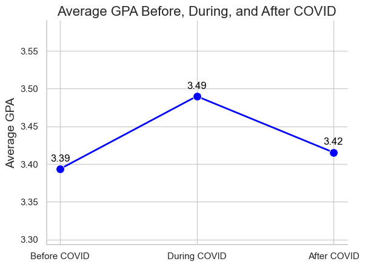

```python
# Calculate the average GPA for each period
avg_gpa_before = courses_before_covid['GPA'].mean()
avg_gpa_during = courses_during_covid['GPA'].mean()
avg_gpa_after = courses_after_covid['GPA'].mean()

# Plot the average GPA for each period
x_labels = ['Before COVID', 'During COVID', 'After COVID']
y_values = [avg_gpa_before, avg_gpa_during, avg_gpa_after]

# Set the style for the plot
sns.set(style="whitegrid")

# Create a line plot with custom markers and colors
fig, ax = plt.subplots()
line_plot = sns.lineplot(x=x_labels, y=y_values, marker='o', markersize=10, linewidth=2, color='blue')

# Customize the plot appearance
ax.set_ylabel('Average GPA', fontsize=14)
ax.set_title('Average GPA Before, During, and After COVID', fontsize=16)
ax.set_ylim(np.min(y_values) - 0.1, np.max(y_values) + 0.1)  # Set y-axis limits

# Annotate data points with their values
for i, value in enumerate(y_values):
    ax.text(i, value + 0.01, f'{value:.2f}', ha='center', fontsize=12, color='black')

# Remove top and right spines for a cleaner look
sns.despine()

plt.show()
```

# Aggregate Insights on Student Performance

Upon examining the data, there is a minor difference in academic performance between the pre/post COVID periods and the duration of the COVID pandemic (with a difference of 0.1 and 0.07, respectively). This raises the question of what factors contributed to this shift in GPAs. Was it due to a higher frequency of top grades, or did the typical distribution of GPAs experience an upward shift during the pandemic? To gain a better understanding of these changes, further analysis is needed.

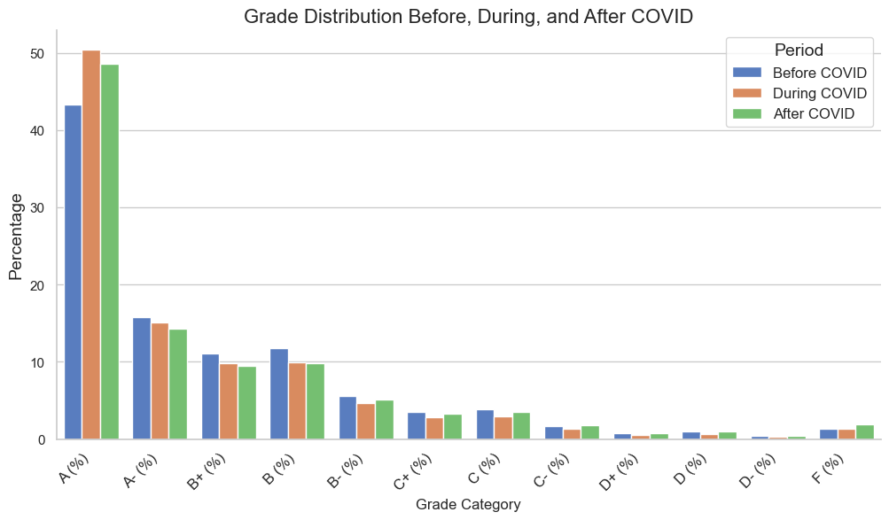

```python
# Calculate the average percentage for each grade category
grade_categories = ['A (%)', 'A- (%)', 'B+ (%)', 'B (%)', 'B- (%)', 'C+ (%)', 'C (%)', 'C- (%)', 'D+ (%)', 'D (%)', 'D- (%)', 'F (%)']
grade_distribution_before = courses_before_covid[grade_categories].mean()
grade_distribution_during = courses_during_covid[grade_categories].mean()
grade_distribution_after = courses_after_covid[grade_categories].mean()

# Prepare data for the grouped bar chart
data = pd.DataFrame({'Grade Category': np.tile(grade_categories, 3),
                     'Percentage': np.concatenate([grade_distribution_before, grade_distribution_during, grade_distribution_after]),
                     'Period': np.repeat(['Before COVID', 'During COVID', 'After COVID'], len(grade_categories))})

# Set the style for the plot
sns.set(style="whitegrid")

# Create a grouped bar chart with custom colors
palette = sns.color_palette("muted", 3)
fig, ax = plt.subplots(figsize=(12, 6))
bar_plot = sns.barplot(x='Grade Category', y='Percentage', hue='Period', data=data, palette=palette, ci=None)

# Customize the plot appearance
ax.set_ylabel('Percentage', fontsize=14)
ax.set_title('Grade Distribution Before, During, and After COVID', fontsize=16)
ax.set_xticklabels(grade_categories, rotation=45, ha='right', fontsize=12)
ax.legend(title='Period', title_fontsize=14, fontsize=12)

# Remove top and right spines for a cleaner look
sns.despine()

plt.show()
```

# Surge in Top Grades

The analysis reveals that the overall increase in GPAs during the pandemic can be attributed to students obtaining A's at a considerably higher rate than before and after COVID. Interestingly, the proportion of students achieving A's did not revert to pre-pandemic levels in the post-COVID period.

While it is evident that students performed better in terms of GPAs during the pandemic compared to the periods before and after, this is only part of the story. Factors such as course withdrawals and drops can also influence the overall GPA outcomes. Consequently, it is worth investigating whether the increase in GPAs during the pandemic was driven by a higher number of course withdrawals.

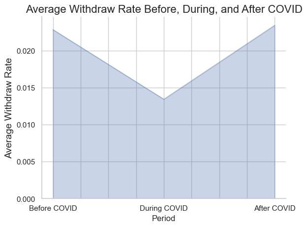

```python
courses_before_covid = courses_before_covid.copy()
courses_during_covid = courses_during_covid.copy()
courses_after_covid = courses_after_covid.copy()

# Calculate the withdraw rate for each period
courses_before_covid.loc[:, 'Withdraw Rate'] = courses_before_covid['Withdraws'] / courses_before_covid['Graded Enrollment']
courses_during_covid.loc[:, 'Withdraw Rate'] = courses_during_covid['Withdraws'] / courses_during_covid['Graded Enrollment']
courses_after_covid.loc[:, 'Withdraw Rate'] = courses_after_covid['Withdraws'] / courses_after_covid['Graded Enrollment']

# Calculate the average withdraw rate for each period
avg_withdraw_rate_before = courses_before_covid['Withdraw Rate'].mean()
avg_withdraw_rate_during = courses_during_covid['Withdraw Rate'].mean()
avg_withdraw_rate_after = courses_after_covid['Withdraw Rate'].mean()

# Plot the average withdraw rate for each period using an area plot
x_labels = ['Before COVID', 'During COVID', 'After COVID']
y_values = [avg_withdraw_rate_before, avg_withdraw_rate_during, avg_withdraw_rate_after]

# Create a DataFrame for the area plot
data = pd.DataFrame({'Period': x_labels, 'Average Withdraw Rate': y_values})

# Create the area plot
fig, ax = plt.subplots()
data.plot.area(x='Period', y='Average Withdraw Rate', ax=ax, alpha=0.3, legend=None)

# Customize the plot appearance
ax.set_ylabel('Average Withdraw Rate', fontsize=14)
ax.set_title('Average Withdraw Rate Before, During, and After COVID', fontsize=16)

# Remove top and right spines for a cleaner look
sns.despine()

plt.show()
```

# Reduced Withdrawals

The analysis indicates that the rise in GPA during the pandemic was unlikely to be a result of increased course withdrawals. Surprisingly, students seemed more inclined to stay in their courses during the COVID period compared to the times before and after.

Since withdrawals do not appear to be the primary reason, I need to explore other factors that could have contributed to the increased GPA during the COVID-19 pandemic. One possible explanation is that students with minimal interest in their coursework may have opted not to return to Virginia Tech during the period of remote learning. This could have led to a shift in the overall student population, favoring those who were more motivated. To investigate this hypothesis, we should first examine the average enrollment for each time period.

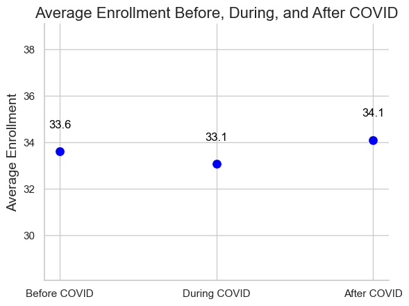

```python
# Calculate the average enrollment for each period
avg_enrollment_before = courses_before_covid['Graded Enrollment'].mean()
avg_enrollment_during = courses_during_covid['Graded Enrollment'].mean()
avg_enrollment_after = courses_after_covid['Graded Enrollment'].mean()

# Plot the average enrollment for each period
x_labels = ['Before COVID', 'During COVID', 'After COVID']
y_values = [avg_enrollment_before, avg_enrollment_during, avg_enrollment_after]

# Set the style for the plot
sns.set(style="whitegrid")

# Create a scatter plot with custom markers and colors
fig, ax = plt.subplots()
scatter_plot = sns.scatterplot(x=x_labels, y=y_values, marker='o', s=100, color='blue')

# Customize the plot appearance
ax.set_ylabel('Average Enrollment', fontsize=14)
ax.set_title('Average Enrollment Before, During, and After COVID', fontsize=16)
ax.set_ylim(np.min(y_values) - 5, np.max(y_values) + 5)  # Set y-axis limits

# Annotate data points with their values
for i, value in enumerate(y_values):
    ax.text(i, value + 1, f'{value:.1f}', ha='center', fontsize=12, color='black')

# Remove top and right spines for a cleaner look
sns.despine()

plt.show()
```

# A Slight Decline in Enrollment

Indeed, there seems to have been a minor dip in enrollment during the COVID-19 pandemic, but the decline was minimal and quickly recovered after the pandemic. Given the limited impact of this factor, it is necessary to consider other potential explanations for the increase in student GPA apart from the initial hypothesis about the nature of online work.

Is it possible that students enrolled in fewer high-credit courses, thereby reducing the workload and demands of each class?

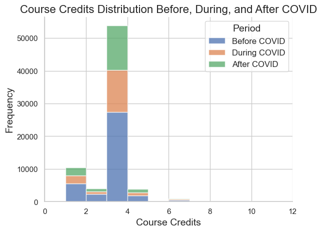

```python
# Set the style for the plot
sns.set(style="whitegrid")

# Create a stacked histogram
fig, ax = plt.subplots()
bins = np.arange(0, courses_before_covid['Credits'].max() + 1, 1)
ax.hist([courses_before_covid['Credits'], courses_during_covid['Credits'], courses_after_covid['Credits']], bins=bins, stacked=True, label=['Before COVID', 'During COVID', 'After COVID'], alpha=0.75)
ax.set_xlim(0, bins[-1])

# Customize the plot appearance
ax.set_xlabel('Course Credits', fontsize=14)
ax.set_ylabel('Frequency', fontsize=14)
ax.set_title('Course Credits Distribution Before, During, and After COVID', fontsize=16)
ax.legend(title='Period', title_fontsize=14, fontsize=12)

# Remove top and right spines for a cleaner look
sns.despine()

plt.show()
```

# Another Subtle Difference

Did the pandemic influence the GPA distribution across different subjects? Could the improvement in student performance be attributed to the selection of different classes? To answer this question, it is necessary to identify the most common courses taken before, during, and after COVID.

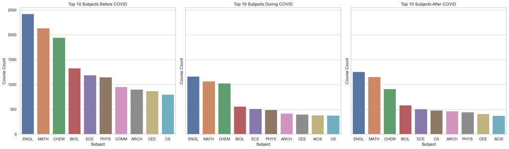

```python
subject_counts_before = courses_before_covid['Subject'].value_counts().reset_index().rename(columns={'index': 'Subject', 'Subject': 'Count'})
subject_counts_during = courses_during_covid['Subject'].value_counts().reset_index().rename(columns={'index': 'Subject', 'Subject': 'Count'})
subject_counts_after = courses_after_covid['Subject'].value_counts().reset_index().rename(columns={'index': 'Subject', 'Subject': 'Count'})

fig, axes = plt.subplots(nrows=1, ncols=3, figsize=(20, 6), sharey=True)
sns.barplot(data=subject_counts_before.head(10), x='Subject', y='Count', ax=axes[0])
axes[0].set_title('Top 10 Subjects Before COVID')
axes[0].set_xlabel('Subject')
axes[0].set_ylabel('Course Count')

sns.barplot(data=subject_counts_during.head(10), x='Subject', y='Count', ax=axes[1])
axes[1].set_title('Top 10 Subjects During COVID')
axes[1].set_xlabel('Subject')
axes[1].set_ylabel('Course Count')

sns.barplot(data=subject_counts_after.head(10), x='Subject', y='Count', ax=axes[2])
axes[2].set_title('Top 10 Subjects After COVID')
axes[2].set_xlabel('Subject')
axes[2].set_ylabel('Course Count')

plt.tight_layout()
plt.show()
```

# Minor Differences in Subjects Taken

There is very little difference in the breakdown of classes between the three time periods. The only distinction between during and before COVID is that communications no longer made the top ten class subjects taken during COVID and was replaced by ACIS.

However, a notable observation is the decrease in total course count during and after COVID compared to pre-COVID levels. It appears that almost all subjects had their course count halved during and post COVID. This seems to indicate that fewer courses were offered as the university consolidated the classes taught.

This leads to the next question: on a departmental basis, what is the difference between the pre-COVID and post-COVID GPA?

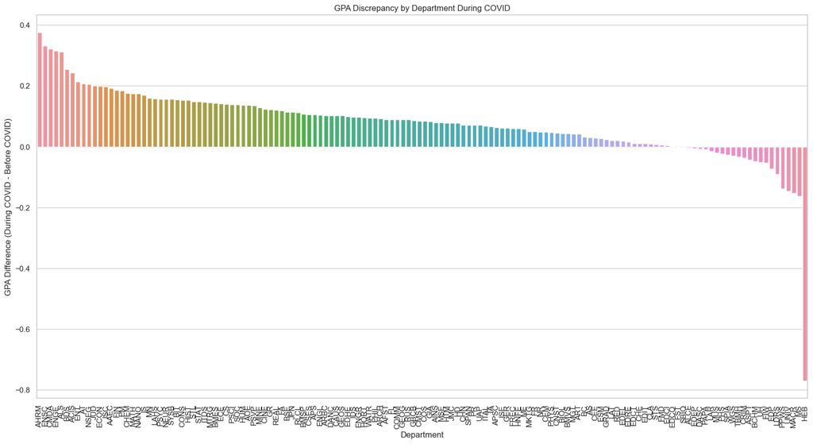

```python
# Group by department and calculate mean GPA
mean_gpa_before_covid = courses_before_covid.groupby('Subject')['GPA'].mean().reset_index()
mean_gpa_during_covid = courses_during_covid.groupby('Subject')['GPA'].mean().reset_index()
mean_gpa_after_covid = courses_after_covid.groupby('Subject')['GPA'].mean().reset_index()

# Merge the results into a single dataframe
mean_gpa_all = mean_gpa_before_covid.merge(mean_gpa_during_covid, on='Subject', suffixes=('_before', '_during'))
mean_gpa_all = mean_gpa_all.merge(mean_gpa_after_covid, on='Subject')
mean_gpa_all.columns = ['Subject', 'Mean GPA Before COVID', 'Mean GPA During COVID', 'Mean GPA After COVID']

# Calculate the difference in mean GPA between before and during COVID
mean_gpa_all['GPA Difference'] = mean_gpa_all['Mean GPA During COVID'] - mean_gpa_all['Mean GPA Before COVID']

# Sort all departments by GPA Difference
all_departments_sorted = mean_gpa_all.sort_values('GPA Difference', ascending=False)

# Create a bar chart for all departments
plt.figure(figsize=(20, 10))
sns.barplot(data=all_departments_sorted, x='Subject', y='GPA Difference')
plt.title('GPA Discrepancy by Department During COVID')
plt.xlabel('Department')
plt.ylabel('GPA Difference (During COVID - Before COVID)')
plt.xticks(rotation=90)
plt.show()
```

# GPA Difference

In line with previous analyses, it is evident that overall, GPA increased during the pandemic compared to pre-pandemic. Only a few departments experienced a lower average GPA.

Given that, what are the top ten departments with increases/decreases in GPA during COVID when compared to the pre-pandemic era?

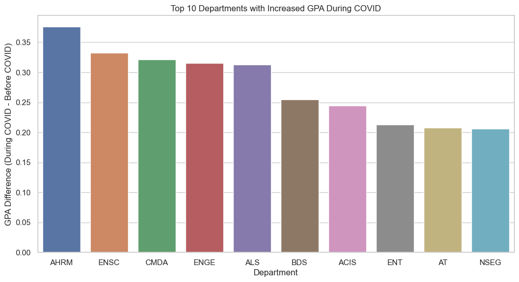

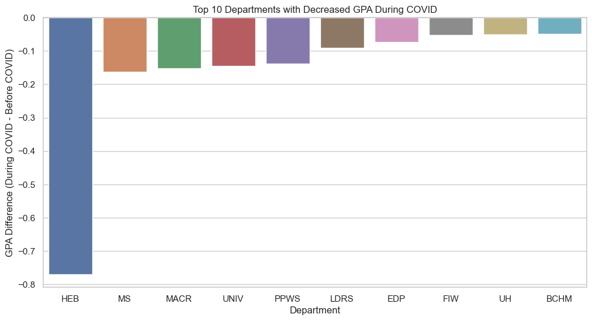

```python
# Calculate the difference in mean GPA between before and during COVID
mean_gpa_all['GPA Difference'] = mean_gpa_all['Mean GPA During COVID'] - mean_gpa_all['Mean GPA Before COVID']

# Sort by GPA Difference and separate into top 10 increased and top 10 decreased
top_10_increased = mean_gpa_all.nlargest(10, 'GPA Difference')
top_10_decreased = mean_gpa_all.nsmallest(10, 'GPA Difference')

# Function to create a bar chart for the top 10 departments
def plot_top_10_departments(data, title):
    plt.figure(figsize=(12, 6))
    sns.barplot(data=data, x='Subject', y='GPA Difference')
    plt.title(title)
    plt.xlabel('Department')
    plt.ylabel('GPA Difference (During COVID - Before COVID)')
    plt.show()

# Create bar charts for the top 10 departments with increased and decreased GPA
plot_top_10_departments(top_10_increased, 'Top 10 Departments with Increased GPA During COVID')
plot_top_10_departments(top_10_decreased, 'Top 10 Departments with Decreased GPA During COVID')
```

# STEM vs. People-Centered Studies

A general trend emerges: STEM classes made up the top ten courses with GPA increases, while classes centered around interactions among people (Hebrew, Military Science, Leadership) constituted the majority of classes that saw GPA decreases.

This raises the question: does this same trend persist after COVID?

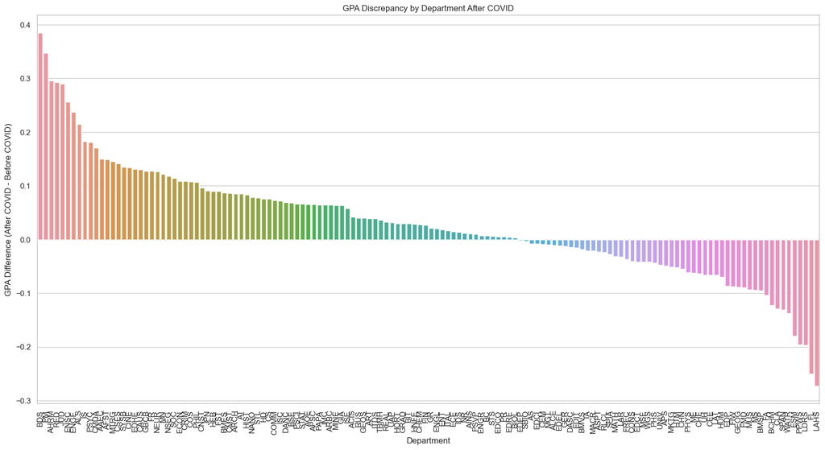

```python
# Calculate the difference in mean GPA between before and after COVID
mean_gpa_all['GPA Difference After'] = mean_gpa_all['Mean GPA After COVID'] - mean_gpa_all['Mean GPA Before COVID']

# Sort all departments by GPA Difference After
all_departments_sorted_after = mean_gpa_all.sort_values('GPA Difference After', ascending=False)

# Create a bar chart for all departments
plt.figure(figsize=(20, 10))
sns.barplot(data=all_departments_sorted_after, x='Subject', y='GPA Difference After')
plt.title('GPA Discrepancy by Department After COVID')
plt.xlabel('Department')
plt.ylabel('GPA Difference (After COVID - Before COVID)')
plt.xticks(rotation=90)
plt.show()
```

# More Balanced, But Still Different

A significant number of classes saw GPA decreases after COVID when compared to the pre-pandemic era, but on the whole, GPA still appeared to increase in the majority of classes.

What subjects made up the top ten of the increases/decreases?

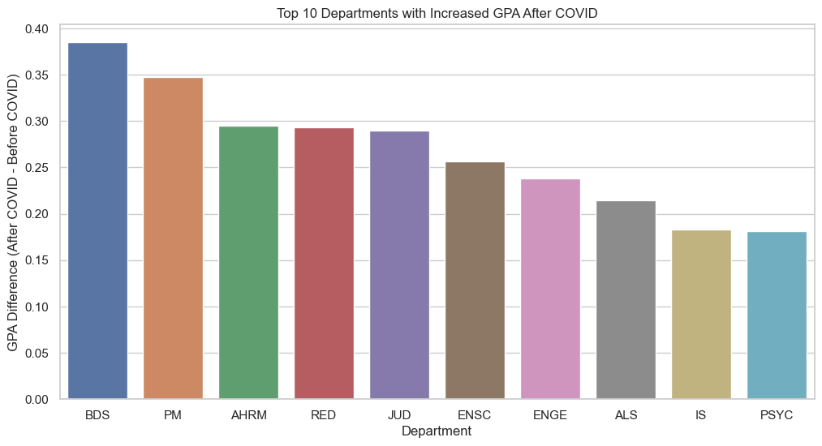

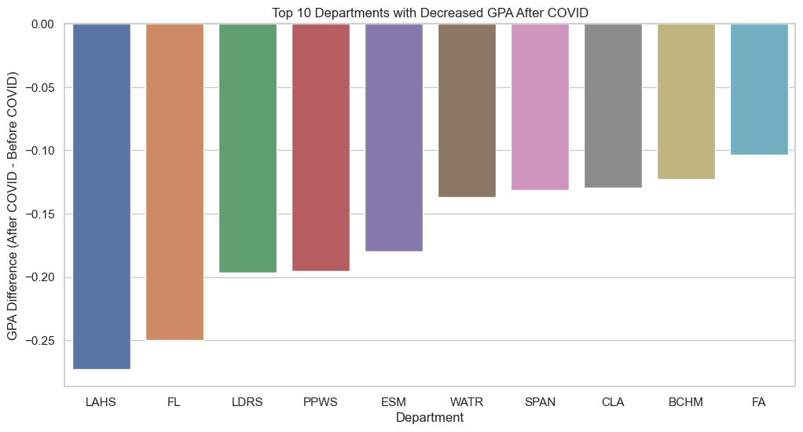

```python
# Calculate the difference in mean GPA between before and during COVID
mean_gpa_all['GPA Difference'] = mean_gpa_all['Mean GPA After COVID'] - mean_gpa_all['Mean GPA Before COVID']

# Sort by GPA Difference and separate into top 10 increased and top 10 decreased
top_10_increased = mean_gpa_all.nlargest(10, 'GPA Difference')
top_10_decreased = mean_gpa_all.nsmallest(10, 'GPA Difference')

# Function to create a bar chart for the top 10 departments
def plot_top_10_departments(data, title):
    plt.figure(figsize=(12, 6))
    sns.barplot(data=data, x='Subject', y='GPA Difference')
    plt.title(title)
    plt.xlabel('Department')
    plt.ylabel('GPA Difference (After COVID - Before COVID)')
    plt.show()

# Create bar charts for the top 10 departments with increased and decreased GPA
plot_top_10_departments(top_10_increased, 'Top 10 Departments with Increased GPA After COVID')
plot_top_10_departments(top_10_decreased, 'Top 10 Departments with Decreased GPA After COVID')
```

# Trend Breaks Down

STEM classes no longer make up the majority of GPA increases, and the subjects that GPA decreases came from across the spectrum.

Do any of these same trends appear by course rather than by subject?

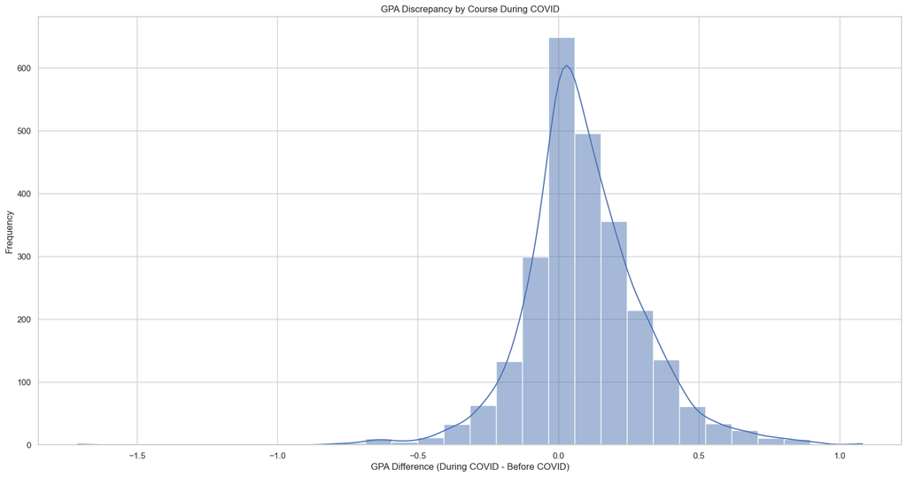

```python
# Group by department and calculate mean GPA
mean_gpa_before_covid = courses_before_covid.groupby('Course Title')['GPA'].mean().reset_index()
mean_gpa_during_covid = courses_during_covid.groupby('Course Title')['GPA'].mean().reset_index()
mean_gpa_after_covid = courses_after_covid.groupby('Course Title')['GPA'].mean().reset_index()

# Merge the results into a single dataframe
mean_gpa_all = mean_gpa_before_covid.merge(mean_gpa_during_covid, on='Course Title', suffixes=('_before', '_during'))
mean_gpa_all = mean_gpa_all.merge(mean_gpa_after_covid, on='Course Title')
mean_gpa_all.columns = ['Course Title', 'Mean GPA Before COVID', 'Mean GPA During COVID', 'Mean GPA After COVID']

# Calculate the difference in mean GPA between before and during COVID
mean_gpa_all['GPA Difference'] = mean_gpa_all['Mean GPA During COVID'] - mean_gpa_all['Mean GPA Before COVID']

# Sort all departments by GPA Difference
all_departments_sorted = mean_gpa_all.sort_values('GPA Difference', ascending=False)

plt.figure(figsize=(20, 10))
sns.histplot(data=all_departments_sorted, x='GPA Difference', bins=30, palette='viridis', kde=True)
plt.title('GPA Discrepancy by Course During COVID')
plt.xlabel('GPA Difference (During COVID - Before COVID)')
plt.ylabel('Frequency')
plt.show()
```

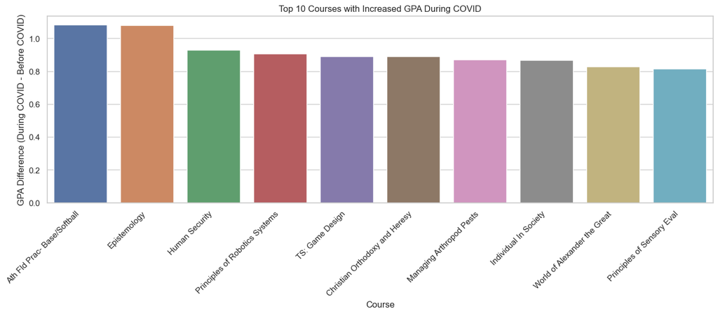

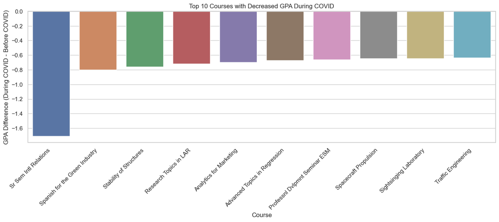

```python
# Calculate the difference in mean GPA between before and during COVID
mean_gpa_all['GPA Difference'] = mean_gpa_all['Mean GPA During COVID'] - mean_gpa_all['Mean GPA Before COVID']

# Sort by GPA Difference and separate into top 10 increased and top 10 decreased
top_10_increased = mean_gpa_all.nlargest(10, 'GPA Difference')
top_10_decreased = mean_gpa_all.nsmallest(10, 'GPA Difference')

# Function to create a bar chart for the top 10 departments
def plot_top_10_departments(data, title):
    plt.figure(figsize=(16, 6))
    ax = sns.barplot(data=data, x='Course Title', y='GPA Difference')
    ax.set_xticklabels(ax.get_xticklabels(), rotation=45, ha='right')
    plt.subplots_adjust(bottom=0.3)
    plt.title(title)
    plt.xlabel('Course')
    plt.ylabel('GPA Difference (During COVID - Before COVID)')
    plt.show()

# Create bar charts for the top 10 departments with increased and decreased GPA
plot_top_10_departments(top_10_increased, 'Top 10 Courses with Increased GPA During COVID')
plot_top_10_departments(top_10_decreased, 'Top 10 Courses with Decreased GPA During COVID')
```

# Again, No Clear Trend

No clear trend emerges when looking at the three graphs above, other affirming the trend that GPA on the whole increased during COVID over pre-pandemic performance.

What about when comparing before and after the pandemic?

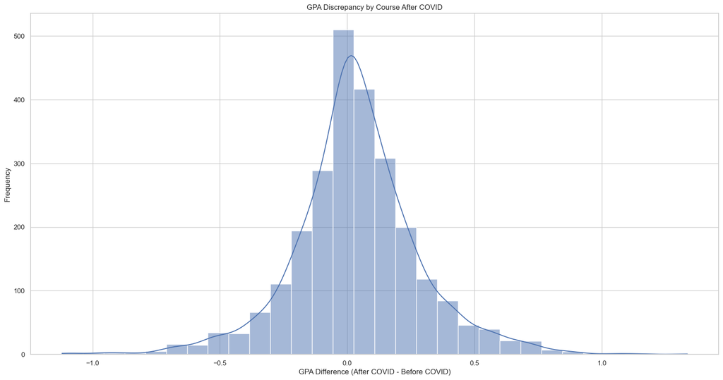

```python
# Calculate the difference in mean GPA between before and during COVID
mean_gpa_all['GPA Difference'] = mean_gpa_all['Mean GPA After COVID'] - mean_gpa_all['Mean GPA Before COVID']

# Sort all courses by GPA Difference
all_departments_sorted = mean_gpa_all.sort_values('GPA Difference', ascending=False)

plt.figure(figsize=(20, 10))
sns.histplot(data=all_departments_sorted, x='GPA Difference', bins=30, palette='viridis', kde=True)
plt.title('GPA Discrepancy by Course After COVID')
plt.xlabel('GPA Difference (After COVID - Before COVID)')
plt.ylabel('Frequency')
plt.show()
```

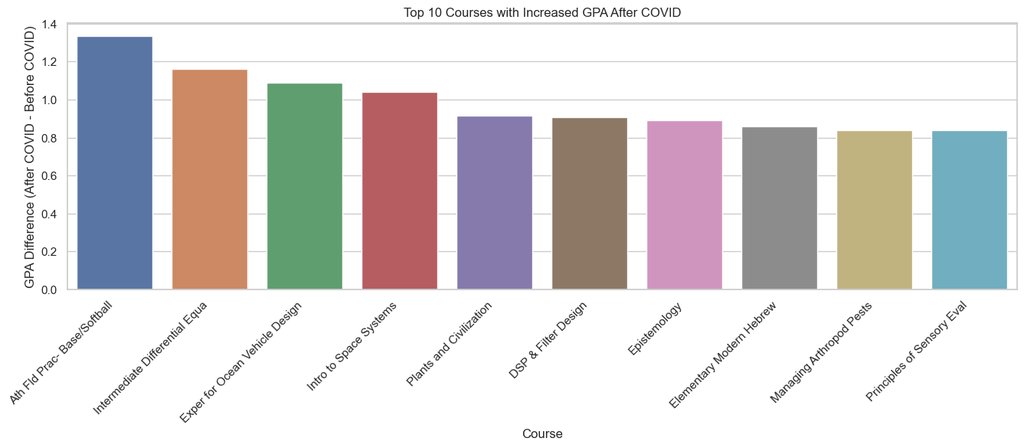

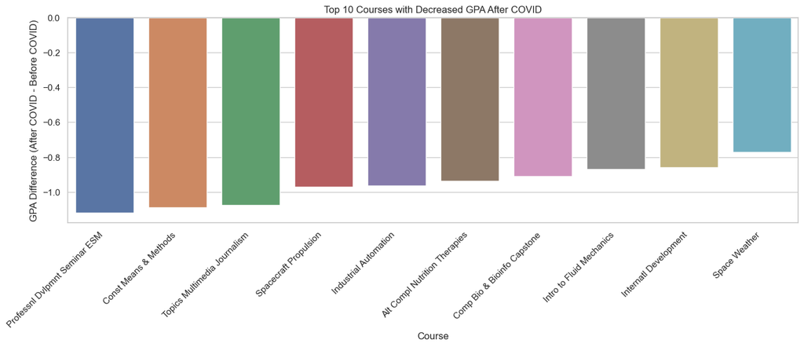

```python
# Calculate the difference in mean GPA between before and during COVID
mean_gpa_all['GPA Difference'] = mean_gpa_all['Mean GPA After COVID'] - mean_gpa_all['Mean GPA Before COVID']

# Sort by GPA Difference and separate into top 10 increased and top 10 decreased
top_10_increased = mean_gpa_all.nlargest(10, 'GPA Difference')
top_10_decreased = mean_gpa_all.nsmallest(10, 'GPA Difference')

# Function to create a bar chart for the top 10 departments
def plot_top_10_departments(data, title):
    plt.figure(figsize=(16, 6))
    ax = sns.barplot(data=data, x='Course Title', y='GPA Difference')
    ax.set_xticklabels(ax.get_xticklabels(), rotation=45, ha='right')
    plt.subplots_adjust(bottom=0.3)
    plt.title(title)
    plt.xlabel('Course')
    plt.ylabel('GPA Difference (After COVID - Before COVID)')
    plt.show()

# Create bar charts for the top 10 departments with increased and decreased GPA
plot_top_10_departments(top_10_increased, 'Top 10 Courses with Increased GPA After COVID')
plot_top_10_departments(top_10_decreased, 'Top 10 Courses with Decreased GPA After COVID')
```

# A Trend in Decreases

No clear trend emerges in the class type of GPA increases after COVID, however it is clear that there is almost a 50-50 split of courses that increased and decreased in GPA. In terms of class type of courses that had a decrease in GPA after COVID, we see that the majority of them (8/10) are STEM classes.

On the whole, it appears that average GPA was consistently higher during COVID than before or after, especially within the realm of STEM subjects. There are a variety of reasons for why this may be, and with one of them surrounding the number of students at Virginia Tech during our given time periods. How did the university grow/shrink during COVID?

```
All - Pre COVID Offered Rate: 69.17%
All - Post COVID Offered Rate: 56.73%
```

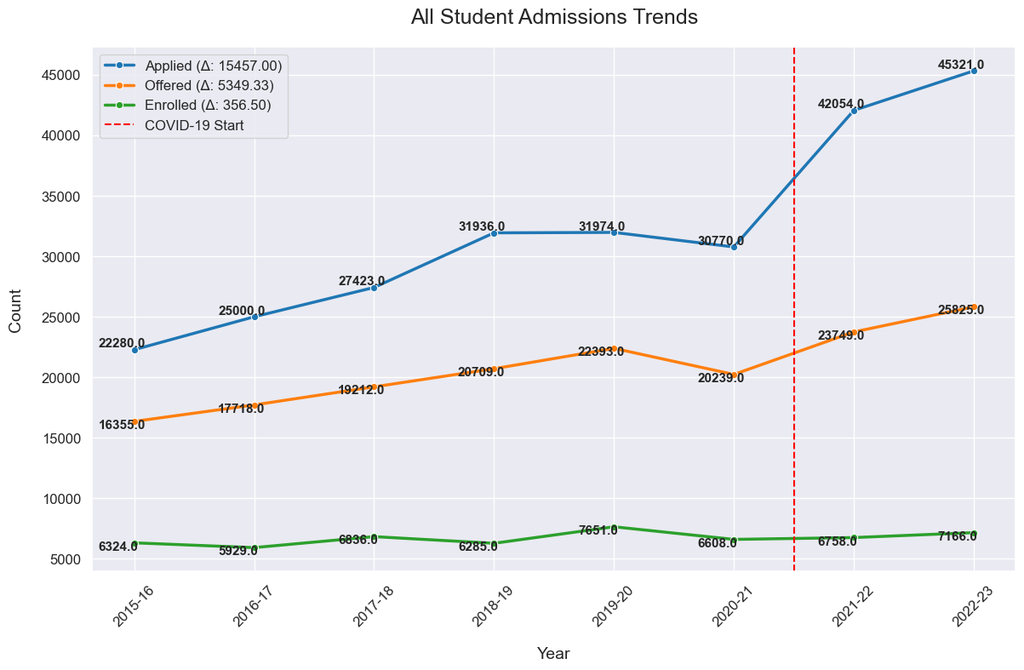

```python
import os

def plot_admissions_trends(csv_file, category='All'):
    # Read the CSV file
    df = pd.read_csv(os.path.join('Admissions', csv_file))

    # Transpose the dataframe and set column names
    df = df.T
    df.columns = df.iloc[0]
    df = df.iloc[1:]
    df.reset_index(inplace=True)
    df.rename(columns={'index': 'Year'}, inplace=True)

    # Calculate average differences before and after COVID
    pre_covid = df[df['Year'] <= '2020-21']
    post_covid = df[df['Year'] >= '2021-22']

    pre_covid_avg = pre_covid[['Applied', 'Offered', 'Enrolled']].mean()
    post_covid_avg = post_covid[['Applied', 'Offered', 'Enrolled']].mean()
    avg_difference = post_covid_avg - pre_covid_avg

    # Calculate offered rates for pre and post COVID
    pre_covid_offered_rate = (pre_covid['Offered'].astype(float) / pre_covid['Applied'].astype(float)).mean()
    post_covid_offered_rate = (post_covid['Offered'].astype(float) / post_covid['Applied'].astype(float)).mean()


    # Plot the trends
    plt.figure(figsize=(14, 8))

    # Customize Seaborn style
    sns.set_style('darkgrid')
    sns.set_palette('tab10')

    # Line plots
    applied_plot = sns.lineplot(x='Year', y='Applied', data=df, label='Applied', marker='o', linewidth=2.5)
    offered_plot = sns.lineplot(x='Year', y='Offered', data=df, label='Offered', marker='o', linewidth=2.5)
    enrolled_plot = sns.lineplot(x='Year', y='Enrolled', data=df, label='Enrolled', marker='o', linewidth=2.5)

    # COVID vertical line (halfway between 2020-21 and 2021-22)
    covid_start_index = df[df['Year'] == '2020-21'].index[0] + 0.5
    plt.axvline(x=covid_start_index, color='red', linestyle='--', label='COVID-19 Start')

    # Add coordinate values
    for index, row in df.iterrows():
        plt.text(index - 0.3, row['Applied'] + 200, row['Applied'], fontsize=11, fontweight='bold')
        plt.text(index - 0.3, row['Offered'] - 600, row['Offered'], fontsize=11, fontweight='bold')
        plt.text(index - 0.3, row['Enrolled'] - 600, row['Enrolled'], fontsize=11, fontweight='bold')

    # Customize plot
    plt.xlabel('Year', fontsize=14, labelpad=15)
    plt.ylabel('Count', fontsize=14, labelpad=15)
    plt.title(f'{category} Student Admissions Trends', fontsize=18, pad=20)
    plt.xticks(df.index, df['Year'], rotation=45, fontsize=12)
    plt.yticks(fontsize=12)

    print(f"{category} - Pre COVID Offered Rate: {pre_covid_offered_rate:.2%}")
    print(f"{category} - Post COVID Offered Rate: {post_covid_offered_rate:.2%}")

    # Add average differences and offered rates to the legend
    legend_labels = [
        f"Applied (Δ: {avg_difference['Applied']:.2f})",
        f"Offered (Δ: {avg_difference['Offered']:.2f})",
        f"Enrolled (Δ: {avg_difference['Enrolled']:.2f})",
        'COVID-19 Start'
    ]

    handles, _ = plt.gca().get_legend_handles_labels()
    plt.legend(handles=handles, labels=legend_labels, fontsize=12)

    plt.show()

# Call the function with the example CSV file
plot_admissions_trends('Student_Admissions.csv', category='All')
```

# Significant Difference in Admissions

Enrollments have remained relatively static when comparing before and after COVID-19. However, total applications and admittance offerings have increased significantly, with the number of applications between the years of 2020-21 and 2021-22 increasing by roughly 11,000. Additionally, over that same course of time, the number of admittances offered increased as well, by about 3500. This informs us that COVID-19 gave Virginia Tech a significantly larger application pool to draw students from and offer admittance to.

How does this break down by student demographics? For this study, we'll be using gender, first-gen status, in-state status, international status, and race as the demographics of interest.

```
Male - Pre COVID Offered Rate: 65.88%
Male - Post COVID Offered Rate: 52.91%
Female - Pre COVID Offered Rate: 73.86%
Female - Post COVID Offered Rate: 61.87%
```

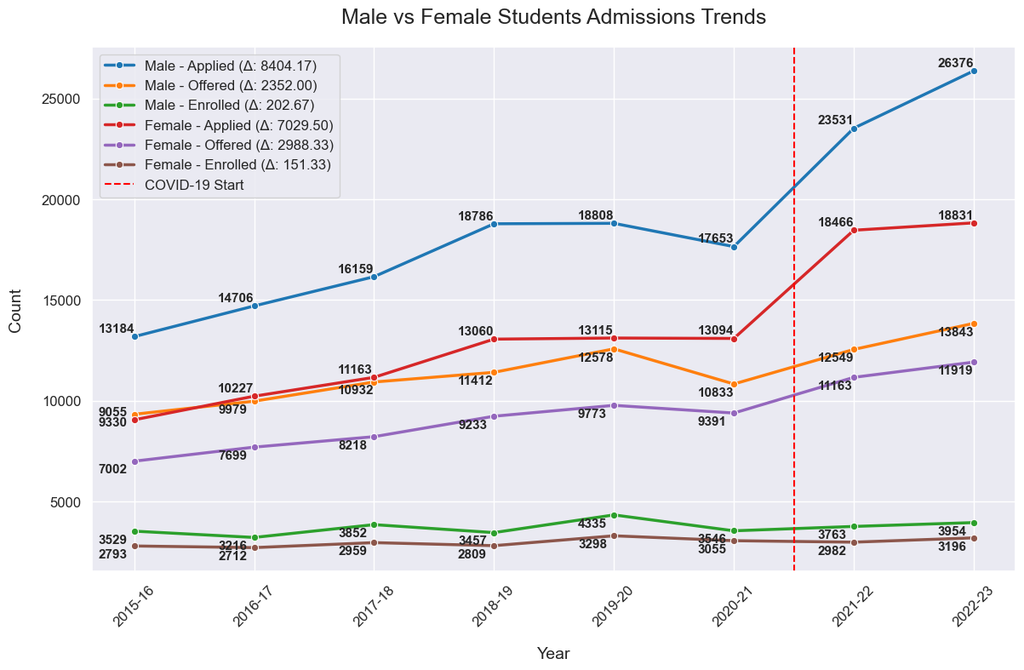

```python
def plot_multiple_admissions_trends(csv_files, categories, title='Student Admissions Trends'):
    plt.figure(figsize=(14, 8))

    # Customize Seaborn style
    sns.set_style('darkgrid')
    sns.set_palette('tab10')

    legend_labels = []
    handles = []

    for csv_file, category in zip(csv_files, categories):
        # Read the CSV file
        df = pd.read_csv(os.path.join('Admissions', csv_file))

        # Transpose the dataframe and set column names
        df = df.T
        df.columns = df.iloc[0]
        df = df.iloc[1:]
        df.reset_index(inplace=True)
        df.rename(columns={'index': 'Year'}, inplace=True)

        # Calculate average differences before and after COVID
        pre_covid = df[df['Year'] <= '2020-21']
        post_covid = df[df['Year'] >= '2021-22']

        pre_covid_avg = pre_covid[['Applied', 'Offered', 'Enrolled']].mean()
        post_covid_avg = post_covid[['Applied', 'Offered', 'Enrolled']].mean()
        avg_difference = post_covid_avg - pre_covid_avg

        # Calculate offered rate for pre and post COVID
        pre_covid_offered_rate = (pre_covid['Offered'] / pre_covid['Applied']).mean() * 100
        post_covid_offered_rate = (post_covid['Offered'] / post_covid['Applied']).mean() * 100

        # Line plots with coordinate values
        for col in ['Applied', 'Offered', 'Enrolled']:
            plot = sns.lineplot(x='Year', y=col, data=df, marker='o', linewidth=2.5)
            handles.append(plot.lines[-1])
            legend_labels.append(f"{category} - {col} (Δ: {avg_difference[col]:.2f})")

            for index, row in df.iterrows():
                value = row[col]
                y_offset = 200 if col == 'Applied' else -600
                plt.text(index - 0.3, value + y_offset, int(value), fontsize=11, fontweight='bold')

        # Add offered rate for pre and post COVID to the legend
        print(f"{category} - Pre COVID Offered Rate: {pre_covid_offered_rate:.2f}%")
        print(f"{category} - Post COVID Offered Rate: {post_covid_offered_rate:.2f}%")

    # COVID vertical line (halfway between 2020-21 and 2021-22)
    covid_start_index = df[df['Year'] == '2020-21'].index[0] + 0.5
    plt.axvline(x=covid_start_index, color='red', linestyle='--', label='COVID-19 Start')
    handles.append(plt.gca().lines[-1])
    legend_labels.append('COVID-19 Start')

    # Customize plot
    plt.xlabel('Year', fontsize=14, labelpad=15)
    plt.ylabel('Count', fontsize=14, labelpad=15)
    plt.title(title, fontsize=18, pad=20)
    plt.xticks(df.index, df['Year'], rotation=45, fontsize=12)
    plt.yticks(fontsize=12)

    # Add average differences to the legend
    plt.legend(handles=handles, labels=legend_labels, fontsize=12)

    plt.show()

csv_files = ['Male_Admissions.csv', 'Female_Admissions.csv']
categories = ['Male', 'Female']
title = 'Male vs Female Students Admissions Trends'

plot_multiple_admissions_trends(csv_files, categories, title)
```

# Gender Breakdown is Consistent with the Student Body as a Whole

```
First_Gen - Pre COVID Offered Rate: 61.04%
First_Gen - Post COVID Offered Rate: 59.89%
Non_First_Gen - Pre COVID Offered Rate: 70.65%
Non_First_Gen - Post COVID Offered Rate: 56.09%
```

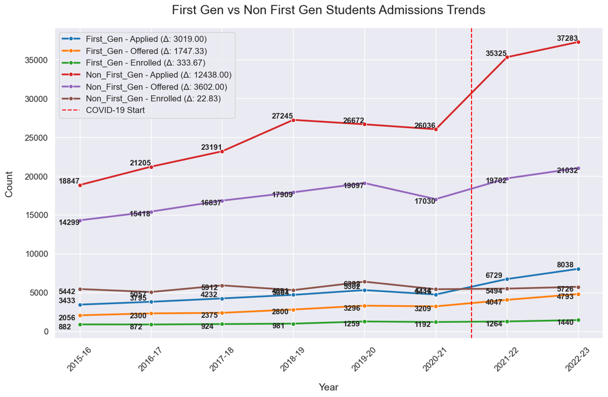

```python
csv_files = ['First_Gen_Admissions.csv', 'Non_First_Gen_Admissions.csv']
categories = ['First_Gen', 'Non_First_Gen']
title = 'First Gen vs Non First Gen Students Admissions Trends'

plot_multiple_admissions_trends(csv_files, categories, title)
```

# First Gen Status Shows Different Behavior Post-Pandemic

```
In_State - Pre COVID Offered Rate: 64.58%
In_State - Post COVID Offered Rate: 46.74%
Out_Of_State - Pre COVID Offered Rate: 74.11%
Out_Of_State - Post COVID Offered Rate: 64.56%
```

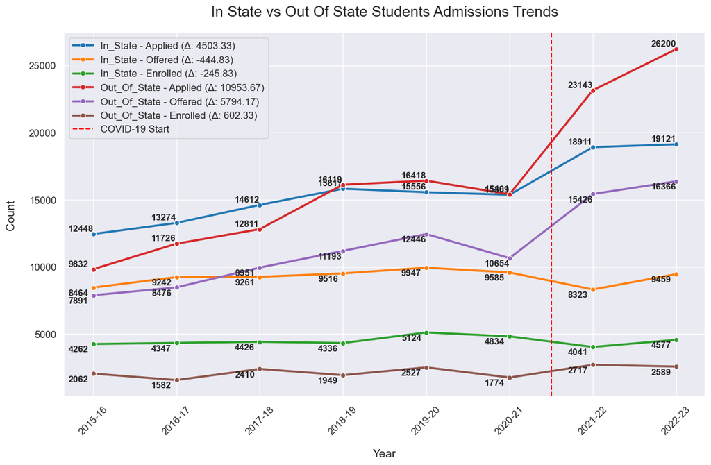

```python
csv_files = ['In_State_Admissions.csv', 'Out_Of_State_Admissions.csv']
categories = ['In_State', 'Out_Of_State']
title = 'In State vs Out Of State Students Admissions Trends'

plot_multiple_admissions_trends(csv_files, categories, title)
```

# Out of State Interest Far Higher Post-Pandemic

```
International - Pre COVID Offered Rate: 68.25%
International - Post COVID Offered Rate: 34.36%
Non_International - Pre COVID Offered Rate: 69.26%
Non_International - Post COVID Offered Rate: 58.27%
```

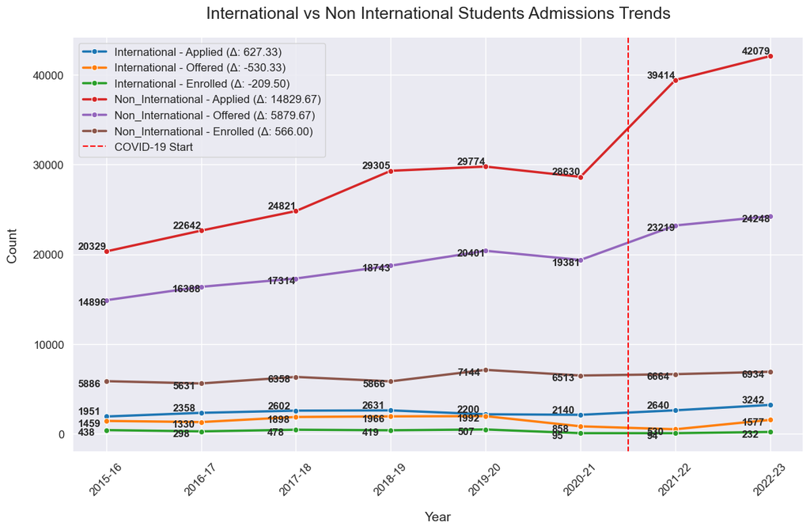

```python
csv_files = ['International_Admissions.csv', 'Non_International_Admissions.csv']
categories = ['International', 'Non_International']
title = 'International vs Non International Students Admissions Trends'

plot_multiple_admissions_trends(csv_files, categories, title)
```

# Fewer Internationals Post-COVID

```
White - Pre COVID Offered Rate: 71.73%
White - Post COVID Offered Rate: 57.43%
```

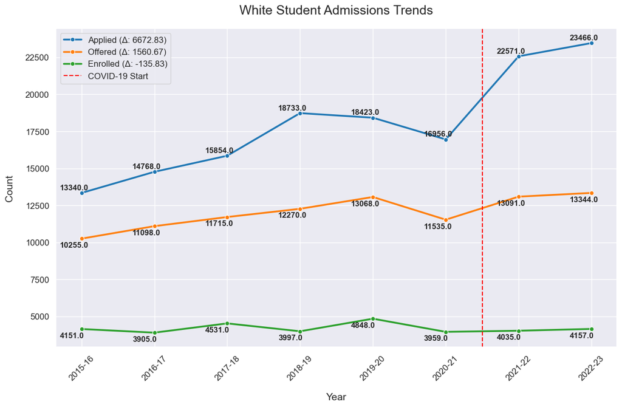

```
Black - Pre COVID Offered Rate: 56.71%
Black - Post COVID Offered Rate: 58.32%
```

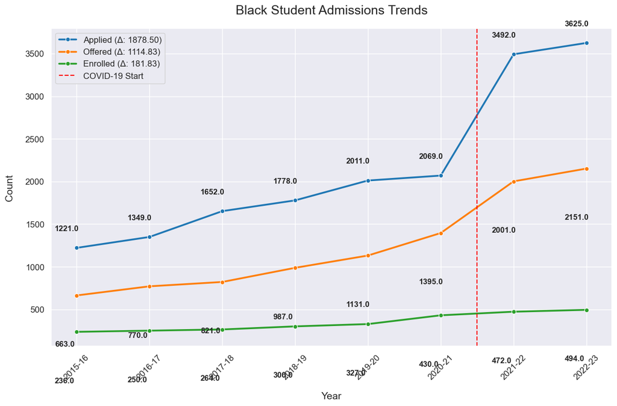

```
Hispanic - Pre COVID Offered Rate: 66.31%
Hispanic - Post COVID Offered Rate: 68.49%
```

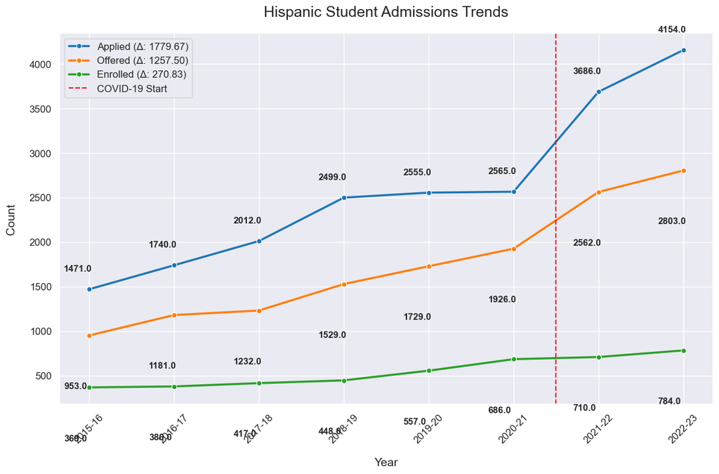

```
Asian - Pre COVID Offered Rate: 67.02%
Asian - Post COVID Offered Rate: 55.30%
```

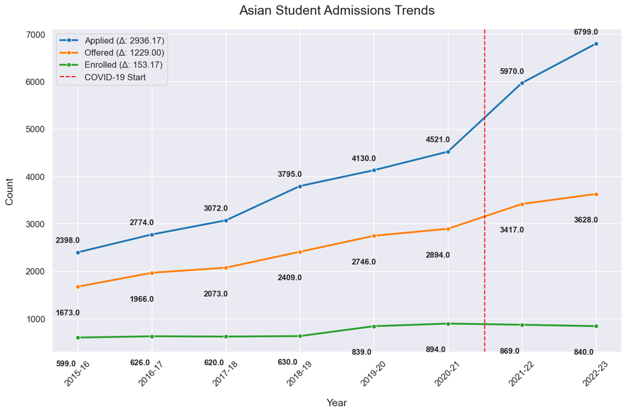

```python
plot_admissions_trends('White_Admissions.csv', category='White')
plot_admissions_trends('Black_Admissions.csv', category='Black')
plot_admissions_trends('Hispanic_Admissions.csv', category='Hispanic')
plot_admissions_trends('Asian_Admissions.csv', category='Asian')
```

# Steady Increases in Applications from All Races, But Decreases in Acceptance Rates for Some

All races (White, Black, Hispanic, and Asian) saw increases in application numbers post-COVID, but their distributions were not all the same.

### White

There was an increase of 1500 offers post-COVID to White students. This is despite White students' acceptance rate falling 14% when compared to pre-COVID rates (down from 71%). Keeping in line with the reduction in acceptance rate, however, was the enrollment: 135 fewer White students enrolled at Virginia Tech post-pandemic.

### Black

There was a significant increase in the number of Black students applying to Virginia Tech post-pandemic, with applications increasing by roughly 1900. This led to an increase in offers (1000) and enrollments (181) when compared to pre-pandemic numbers. Additionally, the overall acceptance rate for Black students increased by 2%, up from 56%.

### Hispanic

Hispanic students also saw an increase in applications, offers, and enrollments, with similar numbers to African-American students (roughly 1800 more applications, 1250 more offers, and 270 more enrollments when compared with pre-pandemic numbers). The acceptance rate of Hispanic students also increased post-COVID by 2%, up from 66%.

### Asian

Asian students had the largest increase in number of applications by minority groups, and also saw an increase in offers and enrollments (roughly 2900 more applications, 1230 more offers, and 153 more enrollments). Interestly, though, they also saw their acceptance rate decrease by 12%, down from 67%.

On the whole, it appears that COVID-19 made Virginia Tech into a much more racially and ethnically diverse university.

## Conclusion Iteration 1

Follow-up questions: How would the increase in the number of withdrawals change the mean GPA? What is the change in GPA for only engineering majors (categorize the majors in these clusters)? When were grades the highest?

## Conclusion Iteration 2

How has the pandemic affected the transition to higher education for high school graduates? The pandemic has witnessed an increase in application numbers from 30,770 students to 42,054 students, but this increase has not been equally distributed among the diversity of students. For instance, Black and Hispanic students have experienced an increase in acceptance rates with about a 2% increase, while White and Asian students have seen a significant decrease, between 12-14%. This can be interpreted as an increase in Virginia Tech's diversity post-pandemic. Consequently, the overall trend post-pandemic and on return from the pandemic has shown a positive trend in applications, offers, and enrollments. The increase in applications could be a result of people having more time during quarantine, thus applying to more colleges. The increase in offers is a direct correlation with the number of applications and possibly more room for each class with the shift to online courses.

Follow-up questions: How has quarantine affected application numbers?

## Credits

All data cleaning, analysis, and visualizations done by Eric Uehling.